# A doc for data visa of survival by survminer

[Zyang](https://github.com/zy1998ld) - 09/19/22

> Date visalition for survival analysis may divided into 3 parts,described in [survminer](https://rpkgs.datanovia.com/survminer/reference/index.html)

# Get the lung data

Always start by loading *survival*. The [survival](https://www.tidyverse.org) is officially the package used for survival analysis. [survminer](https://rpkgs.datanovia.com/survminer/reference/index.html) is used for imaging by ggplot. It is a good practice to load all the packages in the same time.

```r
library(tidyverse)
library(rmarkdown)
library(epuRate)
library(survival)
library(survminer)
```

Then I explain what is my input data and I load lung datasheet. Here is how it looks like:

```r
lung %>% head(5)
```

|  | inst | time | status | age | sex | ph.ecog | ph.karno | pat.karno | meal.cal | wt.loss |
| --- | --- | --- | --- | --- | --- | --- | --- | --- | --- | --- |
| 1 | 3 | 306 | 2 | 74 | 1 | 1 | 90 | 100 | 1175 | NA |
| 2 | 3 | 455 | 2 | 68 | 1 | 0 | 90 | 90 | 1225 | 15 |
| 3 | 3 | 1010 | 1 | 56 | 1 | 0 | 90 | 90 | NA | 15 |
| 4 | 5 | 210 | 2 | 57 | 1 | 1 | 90 | 60 | 1150 | 11 |
| 5 | 1 | 883 | 2 | 60 | 1 | 0 | 100 | 90 | NA | 0 |

# Data visalition

Here are 3 parts of a [survival plot](https://rpkgs.datanovia.com/survminer/survminer_cheatsheet.pdf) that you can find in the [survminer cheatsheet](https://rpkgs.datanovia.com/survminer/survminer_cheatsheet.pdf).

## Survival Curver

`ggsurvplot()`is a generic function to plot survival curves. Wrapper around the `ggsurvplot_xx()` family functions. Plot one or a list of `survfit` objects as generated by the `survfit`.`formula()` and `surv_fit` functions

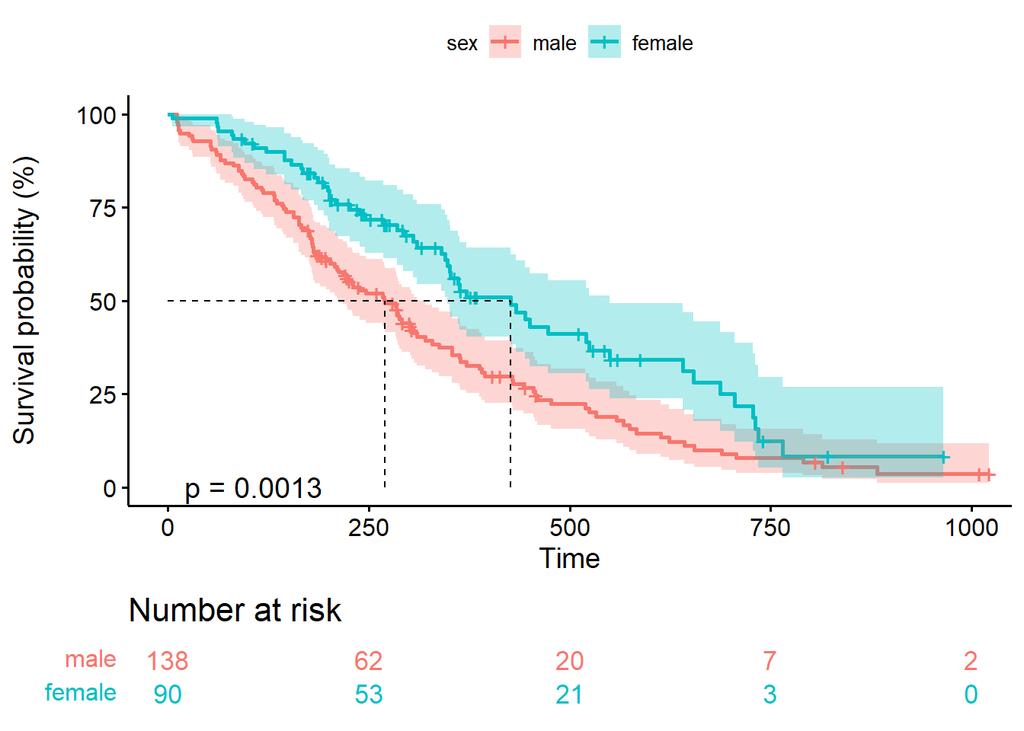

```r
#model buliding
fit <- survfit(Surv(time,status) ~ sex, data = lung)

#survival plot
fit %>%
  ggsurvplot(fun = 'pct',
            pval = T, #add p-value
            risk.table = T, #add risk table
            risk.table.col = 'strata',
            tables.height = 0.2,
            tables.theme = theme_cleantable(),
            surv.median.line = 'hv',
            conf.int = T,
            legend.title = 'sex',
            legend.labs = c('male','female'))
```

### facet plot

The output of `ggsurvfit` includes plot and tables,`facet-grid` can separately facet one of them. Facet plot and tables can see in [survminer](https://rpkgs.datanovia.com/survminer/reference/index.html)

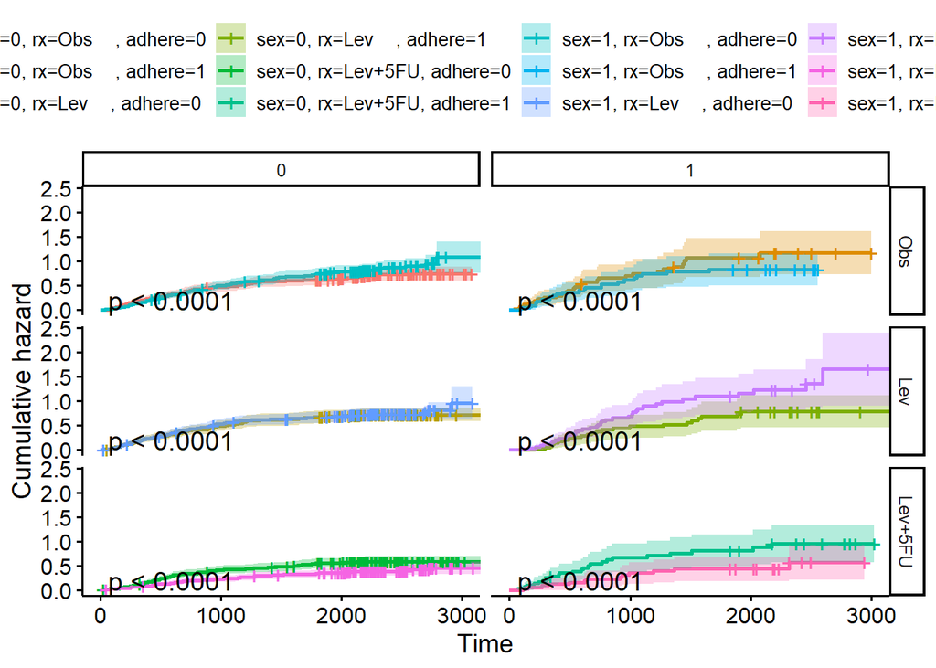

```r
##model buliding
fit2 <- survfit(Surv(time,status)~ sex + rx + adhere, data = colon)

##survival plot
ggsurvplot(fit = fit2,fun = 'cumhaz',
           pval = T,
           risk.table = T,
           conf.int = TRUE,
           risk.table.col = 'strata')$plot +
  facet_grid(rx~adhere)
```

## Diagnostics of Cox Model

The function cox.zph() from survival package may be used to test the proportional hazards assumption for a Cox regression model fit.

### ggcoxzph()

For each covariate it produces plots with scaled Schoenfeld residuals against the time.

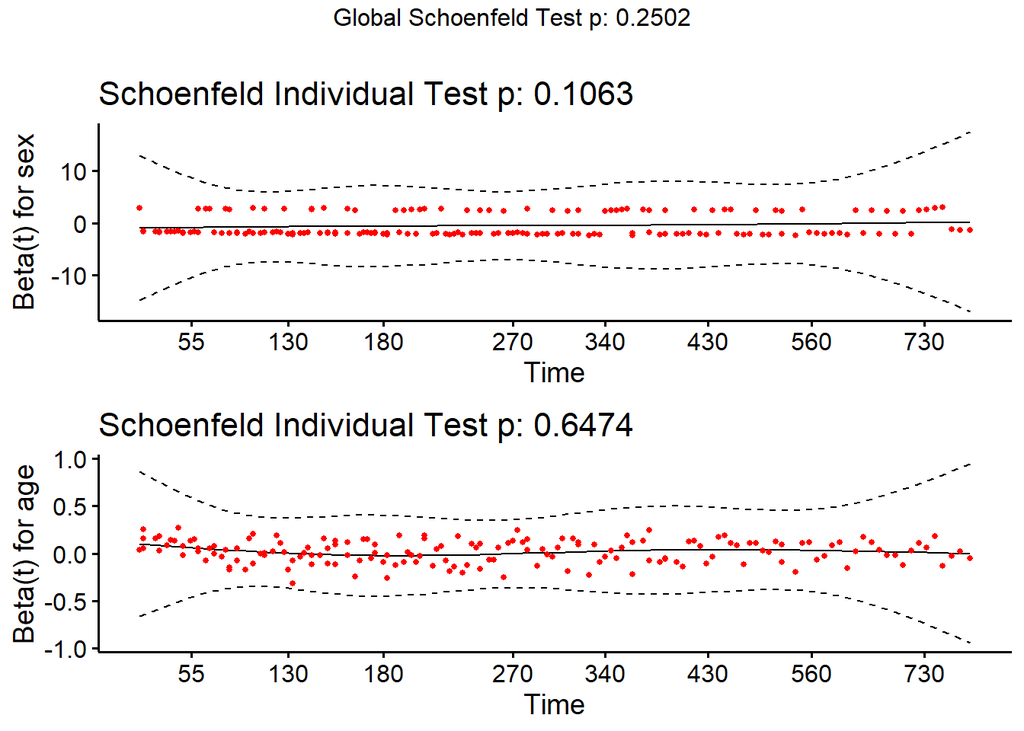

```r
## model buliding
fit3 <- coxph(Surv(time, status) ~ sex + age, data = lung)

## plot
ggcoxzph(cox.zph(fit3),font.min = 12)
```

### ggcoxdiagnostics()

The function `ggcoxdiagnostics()` plots different types of residuals as a function of time, linear predictor or observation id.

> The **type** of residual is selected with type argument. Possible values are “martingale”, “deviance”, “score”, “schoenfeld”, “dfbeta”’, “dfbetas”, and “scaledsch”.

> The **ox.scale** argument defines what shall be plotted on the OX axis. Possible values are “linear.predictions”, “observation.id”, “time”.

> Logical arguments **hline** and **sline** may be used to add horizontal line or smooth line to the plot.

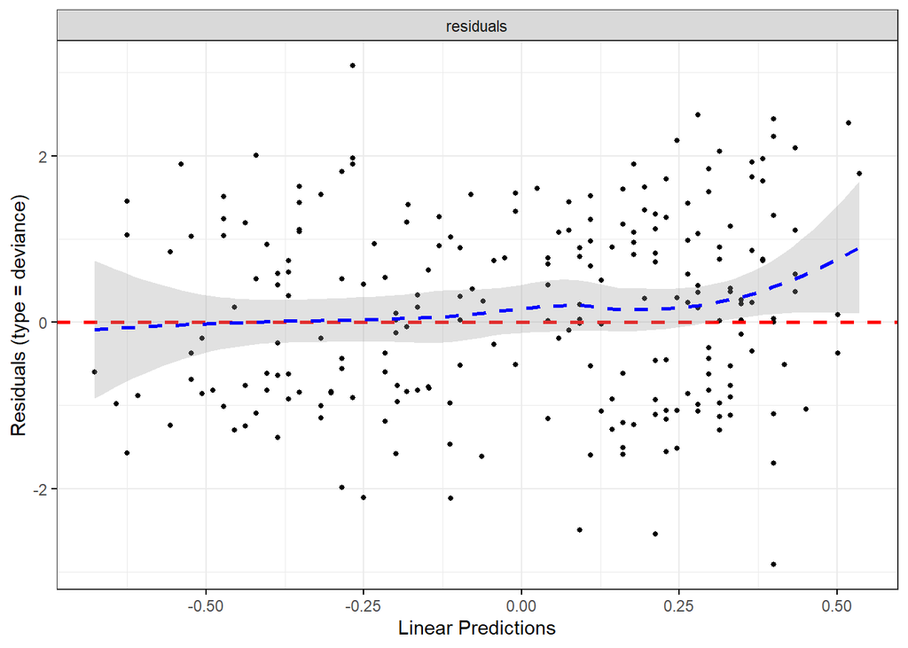

```r
ggcoxdiagnostics(fit = fit3,
                 type = 'deviance',
                 ox.scale = 'linear.predictions')
```

## Summary of Cox Model

The function ggforest() from the survminer package creates a forest plot for a Cox regression model fit. Hazard ratio estimates along with confidence intervals and p-values are plotter for each variable.

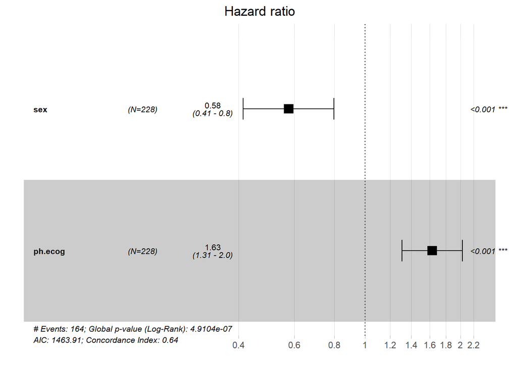

```r
# Create dataset

fit4 <- coxph(Surv(time,status)~sex + ph.ecog,data = lung)

ggforest(fit4)
```

A work by [[Zyang](https://github.com/zy1998ld)](https://github.com/zy1998ld)

*zy1794148812@gmail.com*